# Feb 14 2018

# Packages

These:

```r
library(tidyverse)
library(broom)
```

# review of one-way ANOVA

## The data

```r
my_url="http://www.utsc.utoronto.ca/~butler/d29/hairpain.txt"
hairpain=read_delim(my_url," ")
hairpain
```

| hair | pain |
| --- | --- |
| lightblond | 62 |
| lightblond | 60 |
| lightblond | 71 |
| lightblond | 55 |
| lightblond | 48 |
| darkblond | 63 |
| darkblond | 57 |
| darkblond | 52 |
| darkblond | 41 |
| darkblond | 43 |

[output cut: 9 more lines]

Summary statistics

```r
hairpain %>% group_by(hair) %>%
  summarize( n=n(),
             xbar=mean(pain),
               s=sd(pain))
```

| hair | n | xbar | s |
| --- | --- | --- | --- |
| darkblond | 5 | 51.2 | 9.284396 |
| darkbrown | 5 | 37.4 | 8.324662 |
| lightblond | 5 | 59.2 | 8.526429 |
| lightbrown | 4 | 42.5 | 5.446712 |

Brown-haired people seem to have lower pain tolerance.

Boxplot

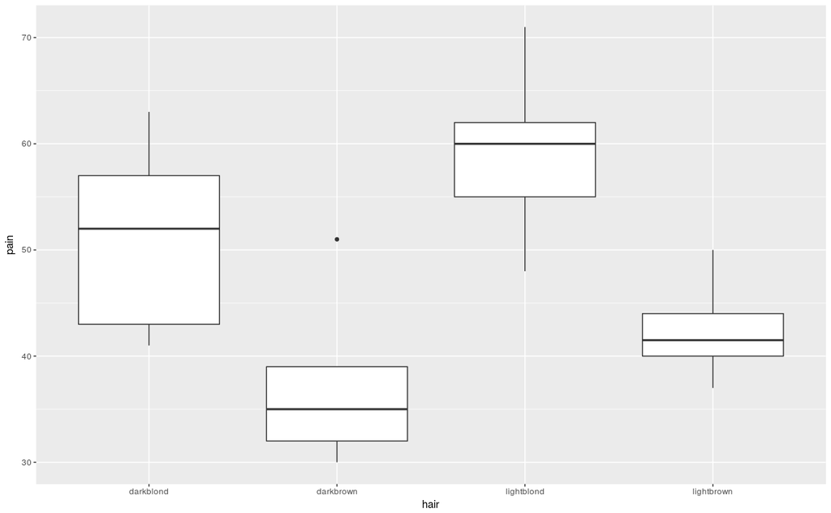

```r
ggplot(hairpain,aes(x=hair,y=pain))+geom_boxplot()
```

## Testing equality of SDs

via **Levene’s test** in package `car`:

```r
car::leveneTest(pain~hair,data=hairpain)
```

```
group coerced to factor.
```

```
Levene's Test for Homogeneity of Variance (center = median)
      Df F value Pr(>F)
group  3  0.3927   0.76
      15
```

- No evidence (at all) of difference among group SDs.
- Possibly because groups *small*.

## Analysis of variance

```r
hairpain.1=aov(pain~hair,data=hairpain)
summary(hairpain.1)
```

```
            Df Sum Sq Mean Sq F value  Pr(>F)
hair         3   1361   453.6   6.791 0.00411 **
Residuals   15   1002    66.8
---
Signif. codes:  0 ‘***’ 0.001 ‘**’ 0.01 ‘*’ 0.05 ‘.’ 0.1 ‘ ’ 1
```

- P-value small: the mean pain tolerances for the four groups are *not* all the same.
- Which groups differ from which, and how?

## Tukey

```r
TukeyHSD(hairpain.1)
```

```
  Tukey multiple comparisons of means
    95% family-wise confidence level

Fit: aov(formula = pain ~ hair, data = hairpain)

$hair
                       diff        lwr        upr     p adj
darkbrown-darkblond   -13.8 -28.696741  1.0967407 0.0740679
lightblond-darkblond    8.0  -6.896741 22.8967407 0.4355768
lightbrown-darkblond   -8.7 -24.500380  7.1003795 0.4147283
lightblond-darkbrown   21.8   6.903259 36.6967407 0.0037079
lightbrown-darkbrown    5.1 -10.700380 20.9003795 0.7893211
lightbrown-lightblond -16.7 -32.500380 -0.8996205 0.0366467
```

## Old-fashioned Tukey

- List group means in order
- Draw lines connecting groups that are *not* significantly different:

```
darkbrown lightbrown  darkblond lightblond
   37.4      42.5       51.2       59.2
   -------------------------
                        ---------------
```

- `lightblond` significantly higher than everything except `darkblond` (at $\alpha=0.05$).
- `darkblond` in middle ground: not significantly less than `lightblond`, not significantly greater than `darkbrown` and `lightbrown`.
- More data might resolve this.
- Looks as if blond-haired people do have higher pain tolerance, but not completely clear.

(other multiple comparison methods in slides)